# Reproducible Research: Peer Assessment 1

ronaldraxon@gmail.com

## Loading and preprocessing the data

### Unzip and reading .csv file

As part of the loading process, the data file is extracted from “activity.zip” which is in the repository. You can download the data set [here.](https://d396qusza40orc.cloudfront.net/repdata%2Fdata%2Factivity.zip)

```r
unzipedFile <- unzip(zipfile='activity.zip',files=c('activity.csv'))
activityData <- read.csv(unzipedFile)
```

### Overview of the data

In order to recognize the features (fields). Here is a list with the first 6 observations

```r
head(activityData)
```

```
##   steps       date interval
## 1    NA 2012-10-01        0
## 2    NA 2012-10-01        5
## 3    NA 2012-10-01       10
## 4    NA 2012-10-01       15
## 5    NA 2012-10-01       20
## 6    NA 2012-10-01       25
```

### Preprocessing the data

Using the [dplyr](https://cran.r-project.org/web/packages/dplyr/index.html) library and its function “filter”, a subset named cData will be created ignoring the missing values.

```r
cData <- filter(activityData, steps != 'NA')
head(cData)
```

```
##   steps       date interval
## 1     0 2012-10-02        0
## 2     0 2012-10-02        5
## 3     0 2012-10-02       10
## 4     0 2012-10-02       15
## 5     0 2012-10-02       20
## 6     0 2012-10-02       25
```

## What is mean total number of steps taken per day?

A table with the variables **ssum_steps**, **avg_steps** and **med_steps** containing the number, mean, and the median of steps taken per day respectively is created as follows:

```r
stepsData <- cData %>%
             group_by(date) %>%
             summarise(sum_steps_per_day = sum(steps),
                       avg_steps_per_day = mean(steps),
                       med_steps = median(steps))
```

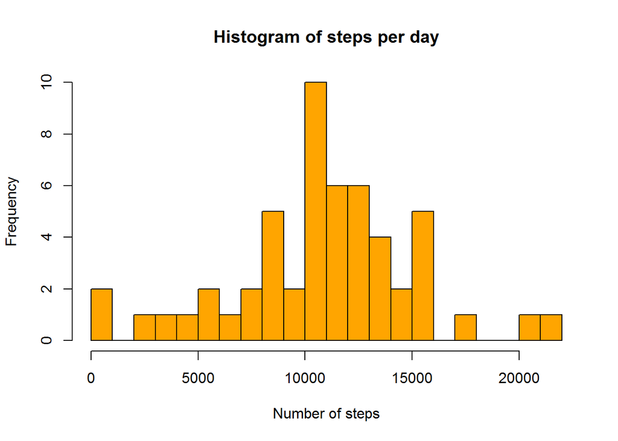

```r
hist(stepsData$sum_steps_per_day,
     breaks = 20,
     include.lowest = TRUE,
     xlab= "Number of steps",
     ylab= "Frequency",
     col= "orange",
     main="Histogram of steps per day")
```

The last plot suggest a high frequency of steps between 1000 and 15000 grouping them by day. Let’s see a decription of the data:

```r
kable(stepsData,caption= "Data Report")
```

Data Report

| date | sum_steps_per_day | avg_steps_per_day | med_steps |
| --- | --- | --- | --- |
| 2012-10-02 | 126 | 0.4375000 | 0 |
| 2012-10-03 | 11352 | 39.4166667 | 0 |
| 2012-10-04 | 12116 | 42.0694444 | 0 |
| 2012-10-05 | 13294 | 46.1597222 | 0 |
| 2012-10-06 | 15420 | 53.5416667 | 0 |
| 2012-10-07 | 11015 | 38.2465278 | 0 |
| 2012-10-09 | 12811 | 44.4826389 | 0 |
| 2012-10-10 | 9900 | 34.3750000 | 0 |
| 2012-10-11 | 10304 | 35.7777778 | 0 |
| 2012-10-12 | 17382 | 60.3541667 | 0 |
| 2012-10-13 | 12426 | 43.1458333 | 0 |
| 2012-10-14 | 15098 | 52.4236111 | 0 |
| 2012-10-15 | 10139 | 35.2048611 | 0 |
| 2012-10-16 | 15084 | 52.3750000 | 0 |
| 2012-10-17 | 13452 | 46.7083333 | 0 |
| 2012-10-18 | 10056 | 34.9166667 | 0 |
| 2012-10-19 | 11829 | 41.0729167 | 0 |
| 2012-10-20 | 10395 | 36.0937500 | 0 |
| 2012-10-21 | 8821 | 30.6284722 | 0 |
| 2012-10-22 | 13460 | 46.7361111 | 0 |
| 2012-10-23 | 8918 | 30.9652778 | 0 |
| 2012-10-24 | 8355 | 29.0104167 | 0 |
| 2012-10-25 | 2492 | 8.6527778 | 0 |
| 2012-10-26 | 6778 | 23.5347222 | 0 |
| 2012-10-27 | 10119 | 35.1354167 | 0 |
| 2012-10-28 | 11458 | 39.7847222 | 0 |
| 2012-10-29 | 5018 | 17.4236111 | 0 |
| 2012-10-30 | 9819 | 34.0937500 | 0 |
| 2012-10-31 | 15414 | 53.5208333 | 0 |
| 2012-11-02 | 10600 | 36.8055556 | 0 |
| 2012-11-03 | 10571 | 36.7048611 | 0 |
| 2012-11-05 | 10439 | 36.2465278 | 0 |
| 2012-11-06 | 8334 | 28.9375000 | 0 |
| 2012-11-07 | 12883 | 44.7326389 | 0 |
| 2012-11-08 | 3219 | 11.1770833 | 0 |
| 2012-11-11 | 12608 | 43.7777778 | 0 |
| 2012-11-12 | 10765 | 37.3784722 | 0 |
| 2012-11-13 | 7336 | 25.4722222 | 0 |
| 2012-11-15 | 41 | 0.1423611 | 0 |
| 2012-11-16 | 5441 | 18.8923611 | 0 |
| 2012-11-17 | 14339 | 49.7881944 | 0 |
| 2012-11-18 | 15110 | 52.4652778 | 0 |
| 2012-11-19 | 8841 | 30.6979167 | 0 |
| 2012-11-20 | 4472 | 15.5277778 | 0 |
| 2012-11-21 | 12787 | 44.3993056 | 0 |
| 2012-11-22 | 20427 | 70.9270833 | 0 |
| 2012-11-23 | 21194 | 73.5902778 | 0 |
| 2012-11-24 | 14478 | 50.2708333 | 0 |
| 2012-11-25 | 11834 | 41.0902778 | 0 |
| 2012-11-26 | 11162 | 38.7569444 | 0 |
| 2012-11-27 | 13646 | 47.3819444 | 0 |
| 2012-11-28 | 10183 | 35.3576389 | 0 |
| 2012-11-29 | 7047 | 24.4687500 | 0 |

```r
avrgStepsPerDay <- format(mean(stepsData$sum_steps_per_day),digits = 2)
avrgOfMeanStepsPerDay <- round(mean(stepsData$avg_steps_per_day),digits = 2)
```

By grouping the observations by date, the average of steps per day is **10766** and the mean of the avarage of steps per day is **37.38**.

## What is the average daily activity pattern?

The **dailyActivityPatterndata** is created by grouping the data by **interval** and getting the average of steps for those intervals.

```r
dailyActivityPattern <- cData %>%
                        group_by(interval) %>%
                        summarise(avg_steps = mean(steps))
```

Here is a time series plot of the 5-minute interval (x-axis) and the average number of steps taken, averaged across all days (y-axis).

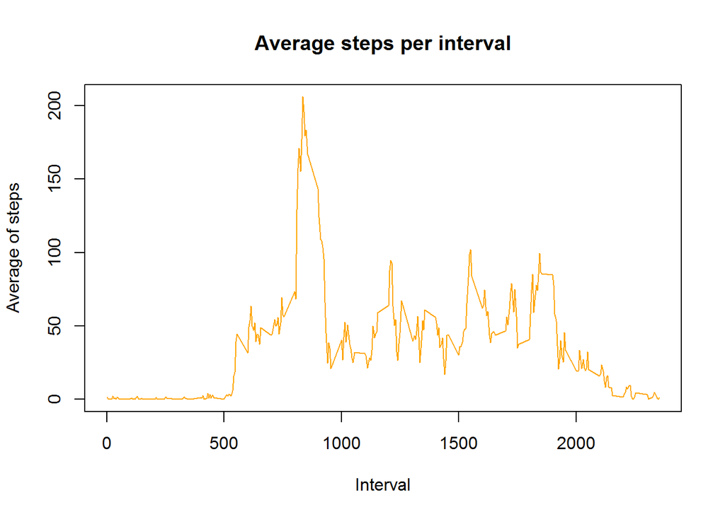

```r
plot(dailyActivityPattern,type="l",
     xlab= "Interval",
     ylab= "Average of steps",
     col= "orange",
     main="Average steps per interval")
```

```r
maxim <- filter(dailyActivityPattern,
                avg_steps==max(dailyActivityPattern$avg_steps))
```

The interval **835** contains the highest number with an average of **206.17** steps.

## Imputing missing values

It is important to know some charasterists for the entire data set. A **Summary** is extracted as follows:

```r
res <- summary(activityData)
```

```
##      steps                date          interval
##  Min.   :  0.00   2012-10-01:  288   Min.   :   0.0
##  1st Qu.:  0.00   2012-10-02:  288   1st Qu.: 588.8
##  Median :  0.00   2012-10-03:  288   Median :1177.5
##  Mean   : 37.38   2012-10-04:  288   Mean   :1177.5
##  3rd Qu.: 12.00   2012-10-05:  288   3rd Qu.:1766.2
##  Max.   :806.00   2012-10-06:  288   Max.   :2355.0
##  NA's   :2304     (Other)   :15840
```

```r
filledSteps <- activityData
for(i in 1:nrow(filledSteps)){
  if(is.na(filledSteps[i,"steps"])){
    value <- filter(dailyActivityPattern,interval==filledSteps[i,"interval"])
    filledSteps[i,"steps"] <- value$avg_steps
  }
}
```

A copy of **activityData** is set into the **filledSteps** variable, then **dailyActivityPattern** subset is used to set the the mean for any 5-minute interval with missing values. Now let’s see a couple observations to check the result

```
##       steps       date interval
## 1 1.7169811 2012-10-01        0
## 2 0.3396226 2012-10-01        5
## 3 0.1320755 2012-10-01       10
## 4 0.1509434 2012-10-01       15
## 5 0.0754717 2012-10-01       20
## 6 2.0943396 2012-10-01       25
```

In the same way as the first point, let’s create another table without NA’s

```r
stepsDataNotNA <- filledSteps %>%
                    group_by(date) %>%
                    summarise(sum_steps_per_day = sum(steps),
                              avg_steps_per_day = mean(steps),
                              med_steps = median(steps))
```

Now we plot the histograms:

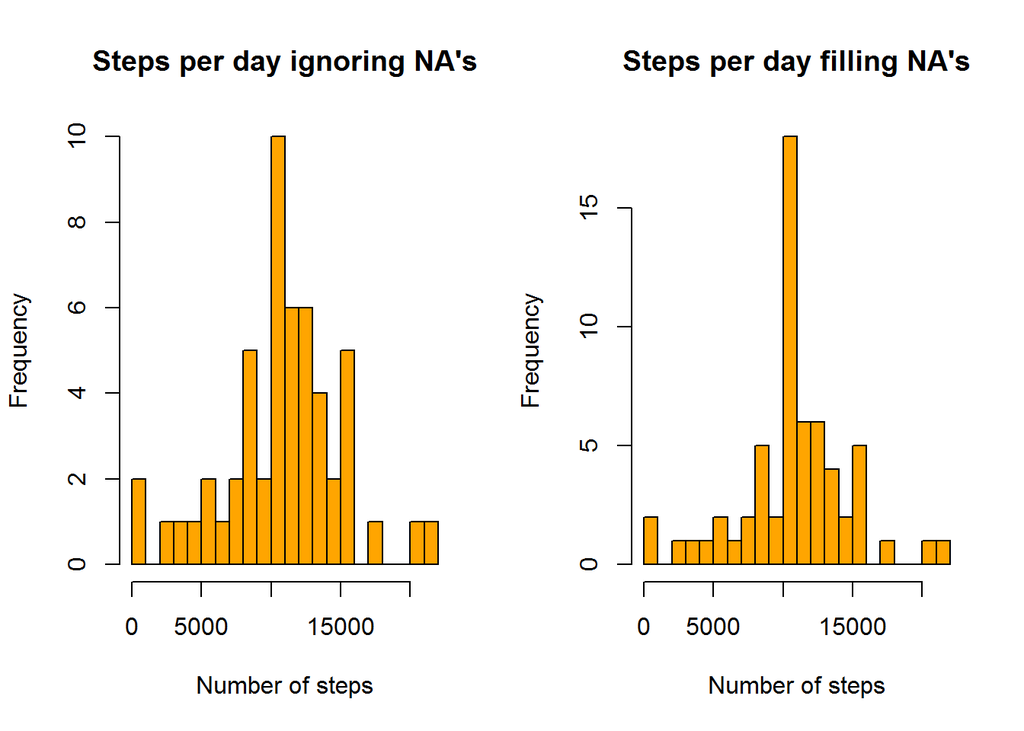

```r
par(mfrow=c(1,2))
hist(stepsData$sum_steps_per_day,
     breaks = 20,
     include.lowest = TRUE,
     xlab= "Number of steps",
     ylab= "Frequency",
     col= "orange",
     main="Steps per day ignoring NA's")
hist(stepsDataNotNA$sum_steps_per_day,
     breaks=20,
     include.lowest = TRUE,
     xlab= "Number of steps",
     ylab= "Frequency",
     col= "orange",
     main="Steps per day filling NA's")
```

```r
avrgStepsNotNA <- format(mean(stepsDataNotNA$sum_steps_per_day),digits = 2)
avrgOfMeanStepsNotNA <- round(mean(stepsDataNotNA$avg_steps_per_day),digits = 2)
```

Apparently, there is not a big difference between ingnoring NA’s and filling them. But it is probably because the process to fix the observations.By grouping the observations by date, the average of steps per day is **10766** and the mean of the avarage of steps per day is **37.38**. These are the same quantities as the first excercise.

## Are there differences in activity patterns between weekdays and weekends?

In order to find differences the weekdaysfilledStepsPerInterval dataset for intervals during weekday and weekends is prepared.Using **weekdays()** function, the name of the day is obtained, given the respective date.

```r
weekdaysfilledSteps <- filledSteps
weekdays <- c('lunes', 'martes', 'miércoles', 'jueves', 'viernes')
weekdaysfilledSteps$day_type <- factor(
                            weekdays(as.Date(filledSteps$date)) %in% weekdays,
                            levels = c('FALSE','TRUE'),
                            labels=c('Weekend','Weekday')
                            )
weekdaysfilledStepsPerInterval <- weekdaysfilledSteps %>%
                                  group_by(interval,day_type) %>%
                                  summarise(avg_steps = mean(steps))
```

And now, we plot the panel:

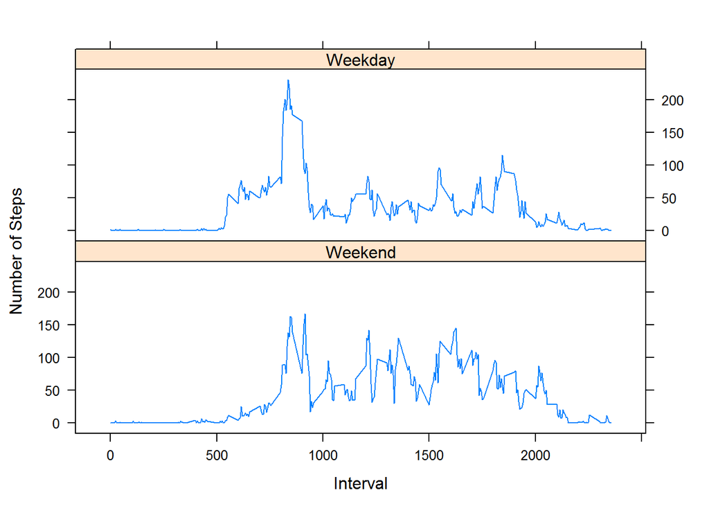

```r
xyplot(avg_steps~interval|day_type,
       data = weekdaysfilledStepsPerInterval,
       type='l',layout=c(1,2),
       xlab='Interval',ylab='Number of Steps')
```

This last plot shows differences in activity patterns between weekdays and weekends, revealing more steps during weekends than weekdays. It would suggest a couple hypothesis such as sedentarism in labor days compared to non labor days.